# My Black Counts: Outreach Experiment

Advancement Project California

### Experiment Summary

- About twenty zip codes were selected each from Alameda County (21) and Los Angeles County (19).
- Within each group of selected zip codes treatment and control zip codes were randomly assigned. Treatment zip codes were targeted with digital outreach while control zip codes were not.
- The experiment ran from 7/19 to 7/26.
- In order to get a sense of context, in this exploratory analysis we are examining response rates in control + treatment zip codes from roughly two weeks before and after the experiment.
- [See the Outreach Experiment Report for more detail.](https://ldaly.github.io/census_temp/MBC_Experiment_3_Draft_Report.html)

## Review Response Rates

#### Average Response Gain Before the Experiment (7/01-7/17)

- Average response rate gain before the experiment was higher in control zip codes than in treatment zip codes, both in Alameda and Los Angeles counties.

| County | Control (%) | Treatment (%) |
| --- | --- | --- |
| Alameda | 0.396 | 0.374 |
| Los Angeles | 0.455 | 0.442 |

[figure not shown]

#### Average Response Rate Gain During the Experiment (7/17 - 7/29)

- On average, treatment ZIP codes (those that were targeted with digital outreach) in Alameda County gained about **0.05 percentage points more** than control ZIP codes in the county.
- On average, treatment ZIP codes (those that were targeted with digital outreach) in Los Angeles County gained about **0.009 percentage points less** than control ZIP codes in the county.
- At this period in the enumeration, self-response rate gains across the state were very small. The state overall only gained about 0.7 percentage points during this period, and so even response rate gains that are relatively small are significant during this time.

| County | Control (%) | Treatment (%) |
| --- | --- | --- |
| Alameda | 0.735 | 0.782 |
| Los Angeles | 0.678 | 0.669 |

[figure not shown]

#### Average Response Gain After the Experiment (7/29-8/14)

- In the two weeks following the experiment, the average self-response rate gain in control zip codes in both Alameda County and Los Angeles County was higher than in the treatment zip codes.
- On average, Alameda control zip codes gained **0.25 points more** than treatment zip codes.
- On average, LA control zip codes gained **0.24 points more** than treatment zip codes.

| County | Control (%) | Treatment (%) |
| --- | --- | --- |
| Alameda | 1.377 | 1.127 |
| Los Angeles | 1.479 | 1.243 |

[figure not shown]

## Visualizing Response Rate Gains Over Time

### Los Angeles County

Review response rates over time in selected zip codes. The gray dashed line indicates the start and end dates of the experiment.

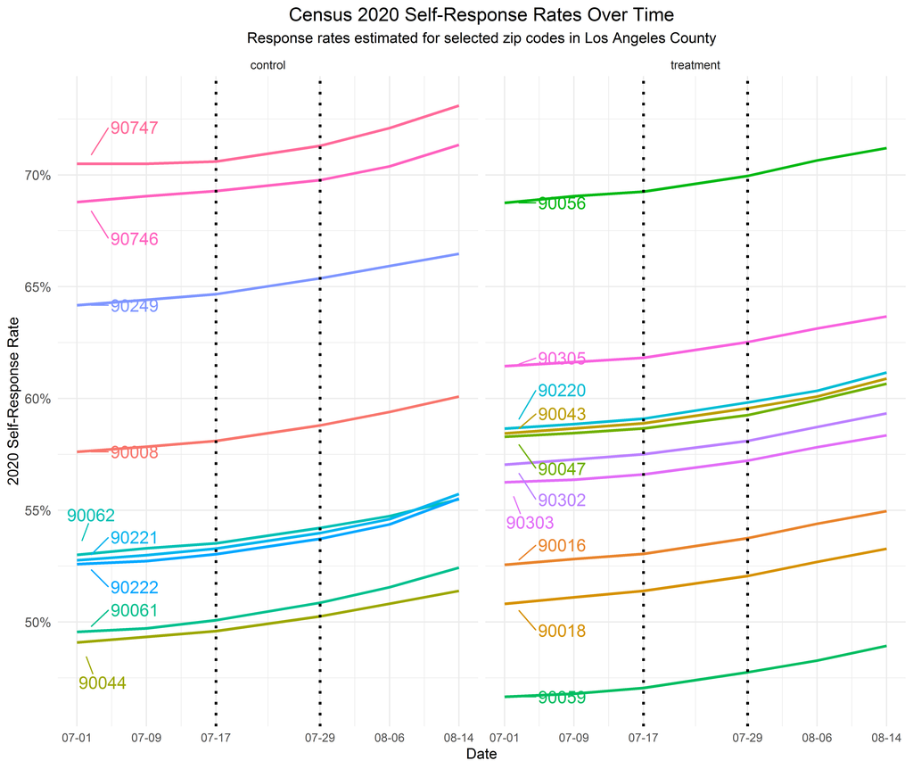

- All selected zip codes in Los Angeles County gained around 2-3 percentage points from 7/01 to 8/14.
- At the start of the experiment (7/17) self-response rates in most zip codes started to increase at a greater rate. For example, zip code 90305 in Inglewood (treatment zip) gained 0.37 percentage points the ~two weeks prior to the experiment (7/01-7/17), and gained 1.31 percentage points the ~two weeks after the experiment started (7/17-8/06).
- Response rates in many regions across the state started to increase at a faster rate around early August. This could be the result of many different things, including concentrated, focused outreach by CBOs and non-profits, Census doorhangers being left by CBOs once COVID-19 restrictions eased up, Census mail reminders being sent out, etc.

### Response Rate Gains Before, During and After the Experiment

#### Los Angeles County

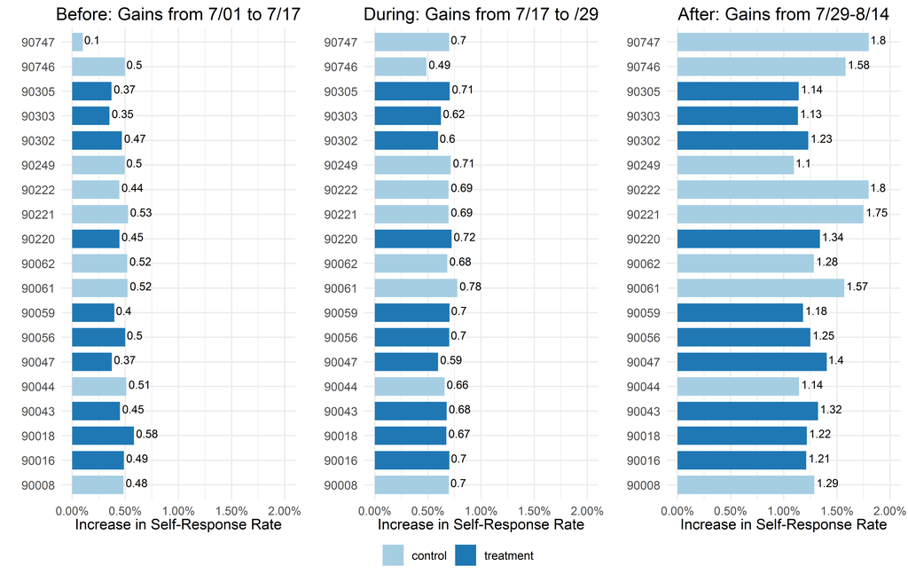

### Alameda County: Response Rate Gains Over Time

Review response rates over time in selected zip codes. The gray dashed line indicates the start and end dates of the experiment.

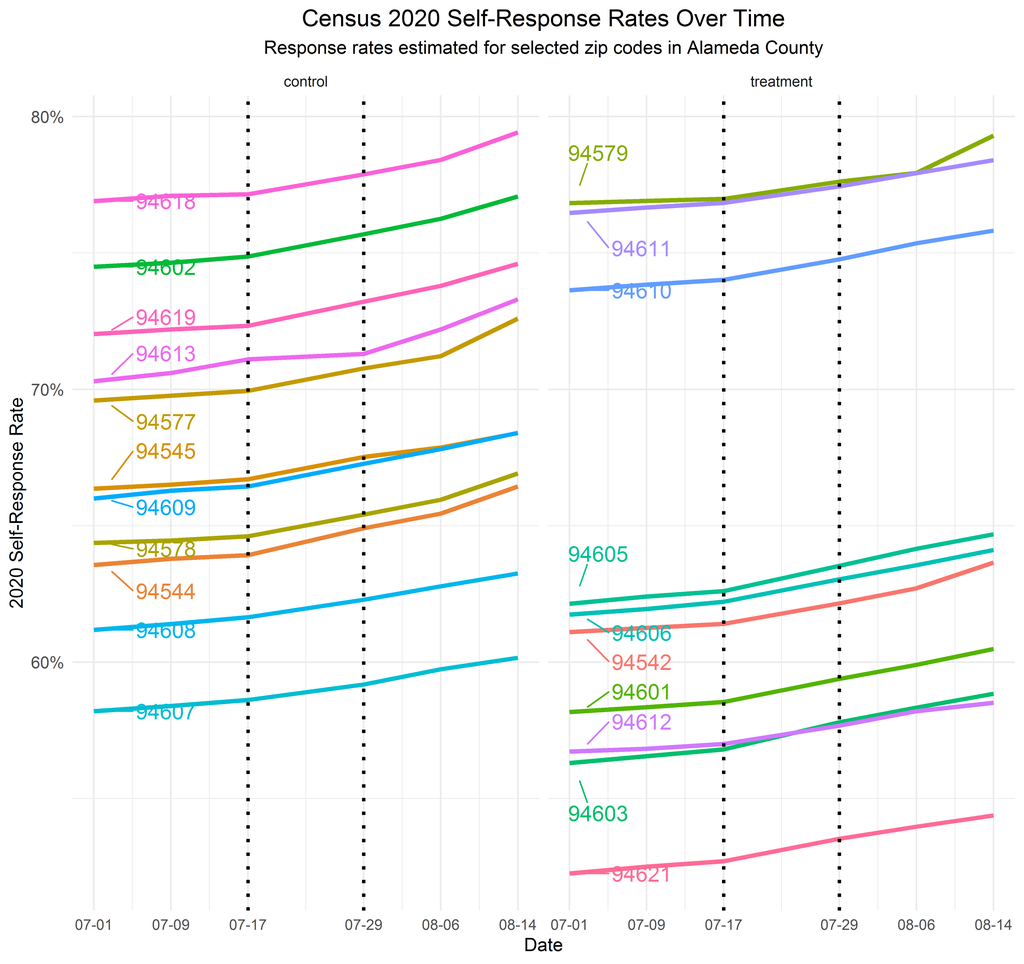

- Selected zip codes in Alameda County gained anywhere from 1.8 to 3 percentage points from 7/01 to 8/14. In Alameda County the 5 zip codes with the highest gain were control zip codes. Treatment zip code gains ranged from 1.8 to 2.6 percentage points over this period.
- At the start of the experiment (7/17) self-response rates in most zip codes started to increase at a greater rate. For example, zip code 94612 in Oakland (treatment zip) gained 0.28 percentage points the ~two weeks prior to the experiment (7/01-7/17), and gained 1.2 percentage points the ~two weeks after the experiment started (7/17-8/06).
- Response rates in many regions across the state started to increase at a faster rate around early August. This could be the result of many different things, including concentrated, focus outreach by CBOs and non-profits, Census doorhangers being left by CBOs once COVID-19 restrictions eased up, Census mail reminders being sent out, etc.

### Response Rate Gains Before, During and After the Experiment

#### Alameda County

[figure not shown]